# Practical Machine Learning Course Project

### Summary

With the popularization of devices such as Jawbone Up, Nike Fuelband and Fitbit, it is now possible to collect large amounts of data about personal activity.

The goal of this project is to create a model which predicts the manner in which an indiviaul did the exercise -in this case, 10 repititions of the Unilateral Dumbbell Biceps Curl- which leads to the outcome defined by the “classe” variable in the training data set.

### Reproducibility

The training data we are using is: https://d396qusza40orc.cloudfront.net/predmachlearn/pml-training.csv

The test data we are using is: https://d396qusza40orc.cloudfront.net/predmachlearn/pml-testing.csv

The data source is: http://groupware.les.inf.puc-rio.br/har

We will set the seed to 10,000.

### Forming The Model

As the goal of this project is to predict the manner in which an individual did the exercise leading to the outcome variable of *classe*, we will look at the five different manners which leads to the outcome. The five different ways the exercise can be done are: 1) Exactly according to the specification (Class A) 2) Throwing the elbows to the front (Class B) 3) Lifting the dumbbell only halfway (Class C) 4) Lowering the dumbbell only halfway (Class D) 5) Throwing the hips to the front (Class E)

We will test two models(RandomForest and Decision Tree) to see which will give us the best result in predicting the way the excercise was done.

### Preparing R

Let’s first download(use the install.packages() function in R to download the below packages if not already installed) and call all the packages we forsee using and setting our seed.

```r
library(caret)
library(randomForest)
```

```r
library(rpart)
library(rpart.plot)
library(RColorBrewer)
library(rattle)
set.seed(10000)
```

### Preparing And Cleaning The Data

First we will import the data.

```r
trainURL <- read.csv(url("http://d396qusza40orc.cloudfront.net/predmachlearn/pml-training.csv"), na.strings=c("NA","#DIV/0!", ""))
testURL <- read.csv(url("http://d396qusza40orc.cloudfront.net/predmachlearn/pml-testing.csv"), na.strings=c("NA","#DIV/0!", ""))
```

Second, remove any columns with no data.

```r
trainINT<- trainURL[,colSums(is.na(trainURL)) == 0]
testINT <- testURL[,colSums(is.na(testURL)) == 0]
```

Third, remove any columns that are not relevent to the prediction of this model.

```r
trainData   <- trainINT[,-c(1:7)]
testData <- testINT[,-c(1:7)]
```

### Partitioning The Data

```r
trainP <- createDataPartition(y=trainData$classe, p=0.7, list=FALSE)
myTrainP <- trainData[trainP, ]
myTestP <- trainData[-trainP, ]
dim(myTrainP)
```

```
## [1] 13737    53
```

```r
dim(myTestP)
```

```
## [1] 5885   53
```

### Testing Random Forest Model

We will develop a model using the Random Forest method and the train data.

```r
trainModRF <- randomForest(classe ~. , data=myTrainP, method = "class")
trainPreRF <- predict(trainModRF, myTestP, type = "class")
```

Let’s use the confusion Matrix to test results and see how well this model fits the data.

```r
confusionMatrix(trainPreRF, myTestP$classe)
```

```
## Confusion Matrix and Statistics
##
##           Reference
## Prediction    A    B    C    D    E
##          A 1674    2    0    0    0
##          B    0 1135    8    0    0
##          C    0    2 1018   11    0
##          D    0    0    0  951    2
##          E    0    0    0    2 1080
##
## Overall Statistics
##
##                Accuracy : 0.9954
##                  95% CI : (0.9933, 0.997)
##     No Information Rate : 0.2845
##     P-Value [Acc > NIR] : < 2.2e-16
##
##                   Kappa : 0.9942
##  Mcnemar's Test P-Value : NA
##
## Statistics by Class:
##
##                      Class: A Class: B Class: C Class: D Class: E
## Sensitivity            1.0000   0.9965   0.9922   0.9865   0.9982
## Specificity            0.9995   0.9983   0.9973   0.9996   0.9996
## Pos Pred Value         0.9988   0.9930   0.9874   0.9979   0.9982
## Neg Pred Value         1.0000   0.9992   0.9984   0.9974   0.9996
## Prevalence             0.2845   0.1935   0.1743   0.1638   0.1839
## Detection Rate         0.2845   0.1929   0.1730   0.1616   0.1835
## Detection Prevalence   0.2848   0.1942   0.1752   0.1619   0.1839
## Balanced Accuracy      0.9998   0.9974   0.9948   0.9931   0.9989
```

We can see that using the Random Forest method, the prediction results are fairly good as there is on average above 99% balanced accuracy for all predictors. Let’s try another method to make sure there is not another model that could do better.

### Testing Decision Tree Model

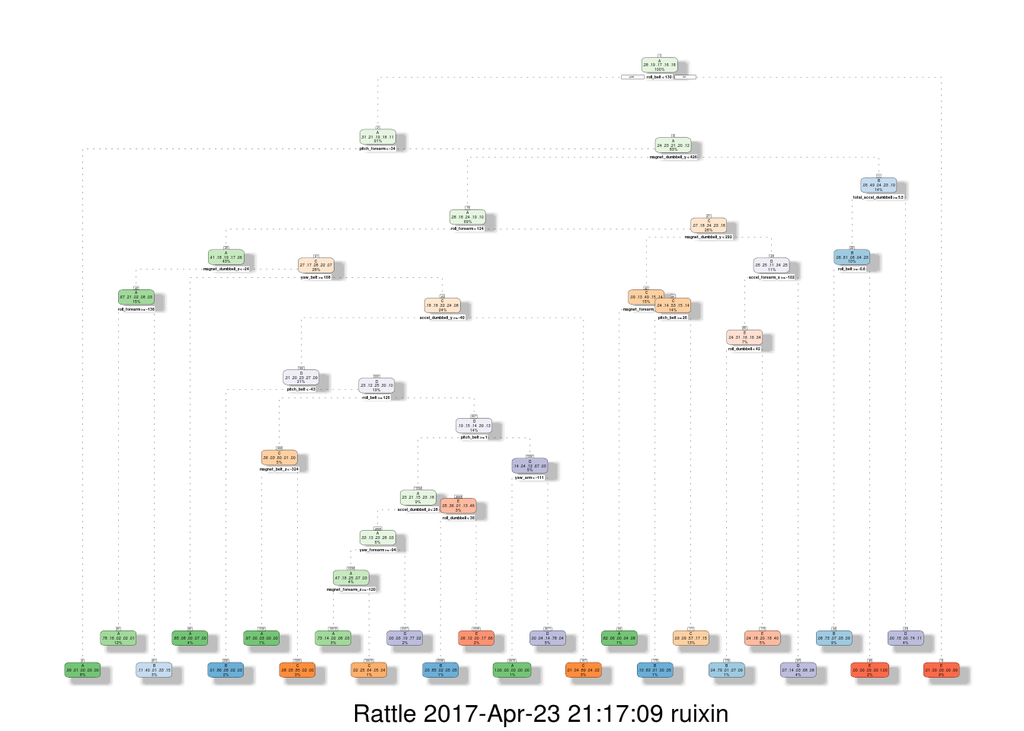

```r
trainModDT <- rpart(classe ~ ., data=myTrainP, method = "class")
fancyRpartPlot(trainModDT)
```

```r
trainPreDT <- predict(trainModDT, myTestP, type = "class")
```

Let’s use the confusion Matrix to test results and see how well this model fits the data.

```r
confusionMatrix(trainPreDT, myTestP$classe)
```

```
## Confusion Matrix and Statistics
##
##           Reference
## Prediction    A    B    C    D    E
##          A 1530  175   21   53   19
##          B   59  679   67   71  109
##          C   41  129  819  153  145
##          D   15   73   57  617   61
##          E   29   83   62   70  748
##
## Overall Statistics
##
##                Accuracy : 0.7465
##                  95% CI : (0.7352, 0.7575)
##     No Information Rate : 0.2845
##     P-Value [Acc > NIR] : < 2.2e-16
##
##                   Kappa : 0.6785
##  Mcnemar's Test P-Value : < 2.2e-16
##
## Statistics by Class:
##
##                      Class: A Class: B Class: C Class: D Class: E
## Sensitivity            0.9140   0.5961   0.7982   0.6400   0.6913
## Specificity            0.9364   0.9355   0.9037   0.9581   0.9492
## Pos Pred Value         0.8509   0.6893   0.6364   0.7497   0.7540
## Neg Pred Value         0.9648   0.9061   0.9550   0.9315   0.9317
## Prevalence             0.2845   0.1935   0.1743   0.1638   0.1839
## Detection Rate         0.2600   0.1154   0.1392   0.1048   0.1271
## Detection Prevalence   0.3055   0.1674   0.2187   0.1398   0.1686
## Balanced Accuracy      0.9252   0.7658   0.8510   0.7991   0.8203
```

We see that the prediction results from the Decision Tree method ranges from 76.58% to 92.52% in balanced accuracy which is not nearly as good as the Random Forest method. We will therefore use the Random Forest Method for the Prediction Quiz.

### Prediction Quiz Formula

```r
predictfinal <- predict(trainModRF, testINT, type="class")
predictfinal
```

```
##  1  2  3  4  5  6  7  8  9 10 11 12 13 14 15 16 17 18 19 20
##  B  A  B  A  A  E  D  B  A  A  B  C  B  A  E  E  A  B  B  B
## Levels: A B C D E
```

```r
preFIN <- predict(trainModRF, testURL, type = "class")
```

Function to generate files with predictions to submit for assignment

```r
pmlResult = function(x){
  n = length(x)
  for(i in 1:n){
    filename = paste0("problem_id_",i,".txt")
    write.table(x[i],file=filename,quote=FALSE,row.names=FALSE,col.names=FALSE)
  }
}

pmlResult(preFIN)
```